# Single cell mouse RNA-seq classification

Load libraries

```r
library(caret, suppressWarnings(TRUE))
```

Load data

```r
file_url <- "https://raw.github.com/hugobowne/machine-learning-in-r/rna_example/mouse_data.csv.gz"
temp <- tempfile()
download.file(file_url, temp)
df <- read.table(gzfile(temp), sep = ",", header = TRUE)
unlink(temp)
```

Delete first column which contain ids

```r
df <- df[,-1]
```

Explore data set

```r
dim(df)
```

```
## [1]  3005 19976
```

As you can see, it’s quite a large data set. There are 3,005 samples each with 19,976 variables. This means the dataframe has 60,027,880 cells! A set this big will not only slow down computation, but it may also cause a memory overflow. Performing a dimentionality reduction (such as PCA) may solve this problem.

Set random seed to achieve reproducible results

```r
set.seed(333)
```

Split into train and test sets

```r
inTraining <- createDataPartition(df$level1class, p=.75, list = FALSE)
df_train <- df[ inTraining,]
df_test <- df[-inTraining,]
```

Pre-process data

```r
# the target variable is level1class in column #3, so we don't want to modify that variable
ppv <- preProcess(df_train[,-3], method = c("center", "scale", "pca", "nzv"))
transformed_train <- predict(ppv, newdata = df_train)
transformed_test <- predict(ppv, newdata = df_test)
```

Let’s compare the original training set with the transformed one.

```r
dim(df_train)
```

```
## [1]  2257 19976
```

```r
format(object.size(df_train), units = "Mb")
```

```
## [1] "174.1 Mb"
```

```r
dim(transformed_train)
```

```
## [1] 2257 1637
```

```r
format(object.size(transformed_train), units = "Mb")
```

```
## [1] "28.3 Mb"
```

Training the KNN model with cross validation and 5 resampling iterations.

```r
knn_fit <- train(level1class ~., data = transformed_train, method = "knn",
                 trControl=trainControl(method = "cv", number = 5),
                 tuneLength = 5)
```

Print the training results

```r
knn_fit
```

```
## k-Nearest Neighbors
##
## 2257 samples
## 1636 predictors
##    7 classes: 'astrocytes_ependymal', 'endothelial-mural', 'interneurons', 'microglia', 'oligodendrocytes', 'pyramidal CA1', 'pyramidal SS'
##
## No pre-processing
## Resampling: Cross-Validated (5 fold)
## Summary of sample sizes: 1805, 1806, 1804, 1806, 1807
## Resampling results across tuning parameters:
##
##   k   Accuracy   Kappa
##    5  0.8763981  0.8413049
##    7  0.8702064  0.8329387
##    9  0.8640008  0.8245317
##   11  0.8520313  0.8085901
##   13  0.8391837  0.7913451
##
## Accuracy was used to select the optimal model using the largest value.
## The final value used for the model was k = 5.
```

The highest accuracy was achieved when $k=5$. We can also plot the variation in accuracy with respect to $k$.

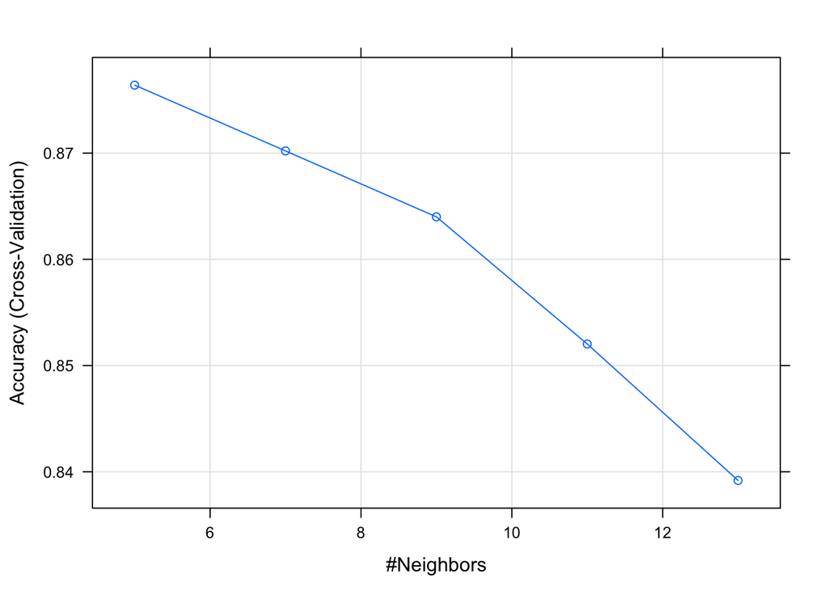

```r
plot(knn_fit)
```

```r
test_pred <- predict(knn_fit, newdata = transformed_test)
```

Finally, we compare our predictions with the original labels.

```r
confusionMatrix(test_pred, transformed_test$level1class)
```

```
## Confusion Matrix and Statistics
##
##                       Reference
## Prediction             astrocytes_ependymal endothelial-mural interneurons
##   astrocytes_ependymal                   49                 0            0
##   endothelial-mural                       2                54            1
##   interneurons                            0                 0           49
##   microglia                               0                 0            0
##   oligodendrocytes                        5                 4            4
##   pyramidal CA1                           0                 0            9
##   pyramidal SS                            0                 0            9
##                       Reference
## Prediction             microglia oligodendrocytes pyramidal CA1
##   astrocytes_ependymal         2                0             2
##   endothelial-mural            3                2             1
##   interneurons                 0                0             0
##   microglia                   11                0             0
##   oligodendrocytes             7              198             9
##   pyramidal CA1                0                0           219
##   pyramidal SS                 1                5             3
##                       Reference
## Prediction             pyramidal SS
##   astrocytes_ependymal            0
##   endothelial-mural               1
##   interneurons                    1
##   microglia                       0
##   oligodendrocytes                8
##   pyramidal CA1                   5
##   pyramidal SS                   84
##
## Overall Statistics
##
##                Accuracy : 0.8877
##                  95% CI : (0.8629, 0.9094)
##     No Information Rate : 0.3128
##     P-Value [Acc > NIR] : < 2.2e-16
##
##                   Kappa : 0.8559
##  Mcnemar's Test P-Value : NA
##
```

[output cut: 23 more lines]

```
## Pos Pred Value                        0.8426               0.9399
## Neg Pred Value                        0.9864               0.9709
## Prevalence                            0.2741               0.3128
## Detection Rate                        0.2647               0.2928
## Detection Prevalence                  0.3142               0.3115
## Balanced Accuracy                     0.9489               0.9543
##                      Class: pyramidal SS
## Sensitivity                       0.8485
## Specificity                       0.9723
## Pos Pred Value                    0.8235
## Neg Pred Value                    0.9768
## Prevalence                        0.1324
## Detection Rate                    0.1123
## Detection Prevalence              0.1364
## Balanced Accuracy                 0.9104
```

We mentioned earlier that a data set large data set might cause problems in computation. In this particular case, if we try training the model with the unreduced training set, there is a memory overflow.

```r
knn_fit <- train(level1class ~., data = df_train, method = "knn",
                 trControl=trainControl(method = "cv", number = 5),
                 preProcess = c("center", "scale", "nzv"),
                 tuneLength = 5)
```

```
## Error: protect(): protection stack overflow
```